# Beach water quality in Ottawa, 2014-2019

One of the nicest things to do on a hot day in the summer is to go for a swim. Ottawa is lucky enough to have a number of beaches to choose from, but I keep hearing people complain about how one beach or another is gross. There are also plenty of opinions online like this one:

> [“Don’t swim at Mooneys, most of the year bacteria levels are beyond ‘safe’ levels and swimming is not recommended, I very rarely ever see people swimming there.”](https://www.reddit.com/r/ottawa/comments/6ogu2l/beach_swimming_in_ottawa/dkhqdyo?utm_source=share&utm_medium=web2x)

Mooney’s Bay in particular seems to get a bad reputation. But in a city where anything remotely unsafe gets shut down, I find it hard to believe that swimming would be encouaged unless the public health risk was basically zero.

Fortunately, there are [water quality records available from the city](http://data.ottawa.ca/en/dataset/beach-water-sampling-data) that might shed some light on whether Mooney’s bay deserves all the trash talk. Note that the historic data don’t seem to be available anymore, but when I downloaded them earlier this summer, records since 2014 were available. If you’re interested in the data, they’re available on the [github repository](https://github.com/nicholas512/swimmR) for this project.

Before getting into the data, here’s a map of the beaches in question. I used the following abbreviations to keep things simple:

- Britiannia (BRT)
- Westboro (WBO)
- Mooney’s Bay (MNY)
- Petrie East Beaches (PEB)
- Petrie River Beaches (PRB)

[interactive chart not shown]

### Water quality data

Beaches are sampled 5 times each day to measure e.coli counts. According to the [Ottawa Public Health Website](http://www.ottawapublichealth.ca/en/public-health-services/beach-water-quality-results.aspx) a no-swim advisory will be issued if:

- the geometric mean of 5 water samples taken on the previous day is greater than 200 E. coli per 100mL of water; or
- a single water sample test result from the previous day is greater than 400 E. coli per 100mL ; or
- there is a significant rainfall event.

It is important to note that since samples take 18 hours to process, you’re relying on the data from the previous day.

### Analysis

After downloading 6 years of water quality data and cleaning it up in R, I wanted to see if there was any pattern in the frequency of no swim advisories across each of the beaches.

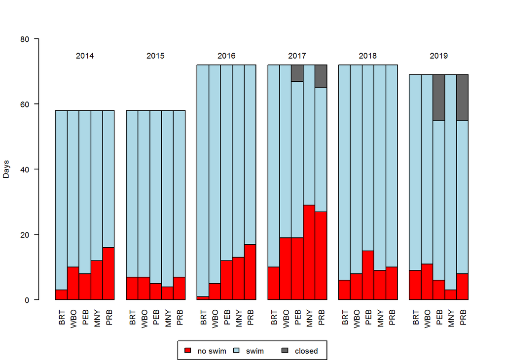

When we look at the overall rate of closures across all years, Britannia is the lowest and is closed only 9% of the time. Westboro, Petrie East and Mooney’s are all closed with approximately the same frequency (~15%), and Petrie River Beaches is closed the most frequently (21%).

Overall frequency of beach closures

|  | closures |
| --- | --- |
| Britannia | 9% |
| Westboro | 15% |
| Petrie East Bay | 16% |
| Mooney’s | 17% |
| Petrie River Beaches | 21% |

But how do these closure frequencies translate into e. coli counts? Looking at the average values for each of the beaches, Britannia has the lowest average counts no matter how the average is calculated. Westboro, Petrie East and Mooney’s have very comparible values and their rank depends on how the average is calculated. Petrie River Beaches on the other hand has consistenly higher counts than any of the others.

Sumamry statistics for e.coli counts

|  | median | mean | geometric_mean |
| --- | --- | --- | --- |
| Britannia | 21.7 | 50.5 | 28.3 |
| Westboro | 39.9 | 80.3 | 44.6 |
| Petrie East Bay | 30.8 | 81.4 | 33.0 |
| Mooney’s | 31.0 | 88.6 | 41.0 |
| Petrie River Beaches | 46.4 | 105.6 | 49.2 |

For those of you who prefer a more visual representation, the distribution of e. coli counts is presented below with a red vertical line reprsenting the cutoff value of 200 for a no swim advisory.

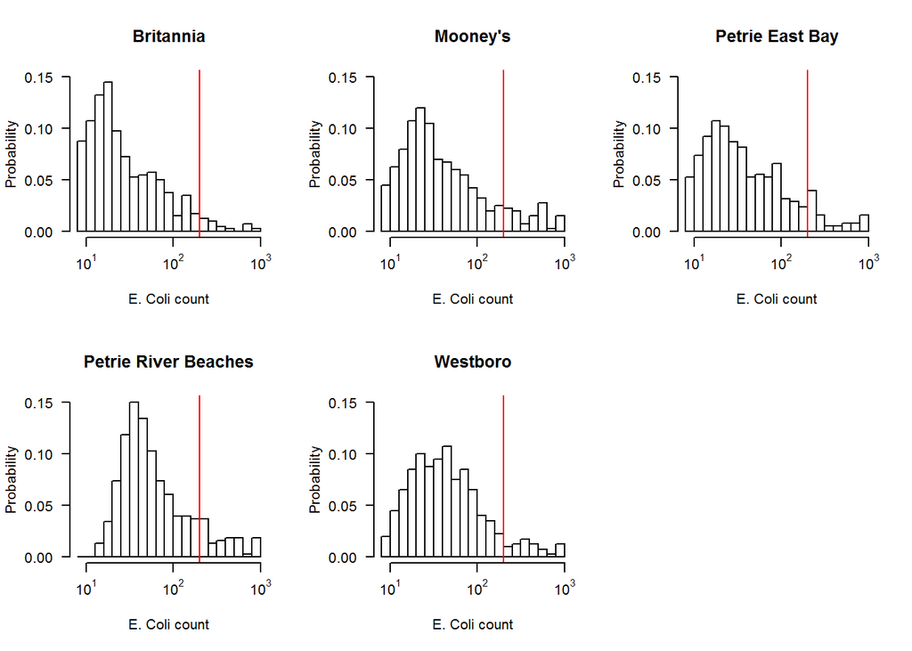

Finally, if the data are split up into ‘swim’ days and ‘no swim’ days it’s possible to find the statistics of e. coli counts on days where swimming is encouraged. Looking at things this way changes the rankings yet again, and suggests that, on average, Westboro has the highest counts on days where swimming is advised. Keep in mind that the average values here mask a lot of variability and that the differences between the beaches is probably not even statistically significant.

E. coli counts on swim days

|  | mean |
| --- | --- |
| BRT | 50 |
| WBO | 68 |
| PEB | 62 |
| MNY | 53 |
| PRB | 65 |

### Tl;dr

The frequency of beach closures depends more on the year than on the beach, with some exceptions. Britannia is generally closed the least and has the lowest e. coli counts.

Westboro, Mooney’s Bay and Petrie East are all closed slightly more frequently, and have more or less the same e. coli counts.

In spite of what the haters might tell you, Mooney’s Bay is actually not a bad place to swim.